# Predicting manner of exercise

David MacGregor

2/23/2017

## Executive Summary

In this report, the creation of a model to predict five classes of exercise based on data collected from accelometers attached to various body parts of exercises, who were then asked to lift weights in various manners. The model created is estimated to accurately predict class of exercise 99% of the time.

## Data

The data used for this report is the Weight Lifting Exercise Dataset from the Human Activity Recognition website (http://groupware.les.inf.puc-rio.br/har). The dataset used to construct and validate the model can be found here: https://d396qusza40orc.cloudfront.net/predmachlearn/pml-training.csv. This is a dataset of 19,622 cases with 160 variables.

The first step was to divide the data into training and validation sets, with 75% of the data in the training set.

```r
library(dplyr)
library(caret)
library(kernlab)
mydata<-read.csv("pmltraining.csv")
```

The first step was to divide the data into training and validation sets, with 75% of the data in the training set.

```r
dim(mydata)
```

[1] 19622 160

```r
set.seed(2003)
inTrain<-createDataPartition(y=mydata$classe, p=.75, list=F)
training<-mydata[inTrain,]
validation<-mydata[-inTrain,]
dim(training)
```

[1] 14718 160

```r
dim(validation)
```

[1] 4904 160 Next we view the training set in RStudio (for the sake of brevity, I do not show the head of the data in this report.)

The data includes several background variables, as well as summary variables such as average and standard deviation, that are irrelevant to the performance, and so those are eliminated.

```r
View(training)

training2<-training[,8:160]
training2<-training2 %>% select(-starts_with("kur"))
training2<-training2 %>% select(-starts_with("skew"))
training2<-training2 %>% select(-starts_with("max"))
training2<-training2 %>% select(-starts_with("min"))
training2<-training2 %>% select(-starts_with("amp"))
training2<-training2 %>% select(-starts_with("var"))
training2<-training2 %>% select(-starts_with("avg"))
training2<-training2 %>% select(-starts_with("stddev"))
```

A look at the distribution of the variables and plots of variables against each other show highly irregular distributions. The following plots show some representative examples.

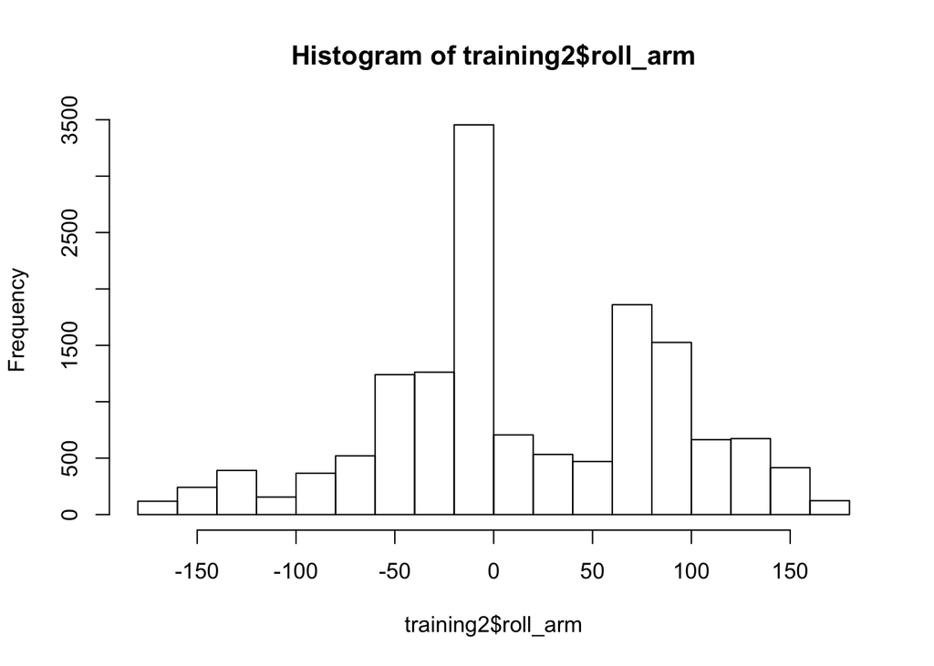

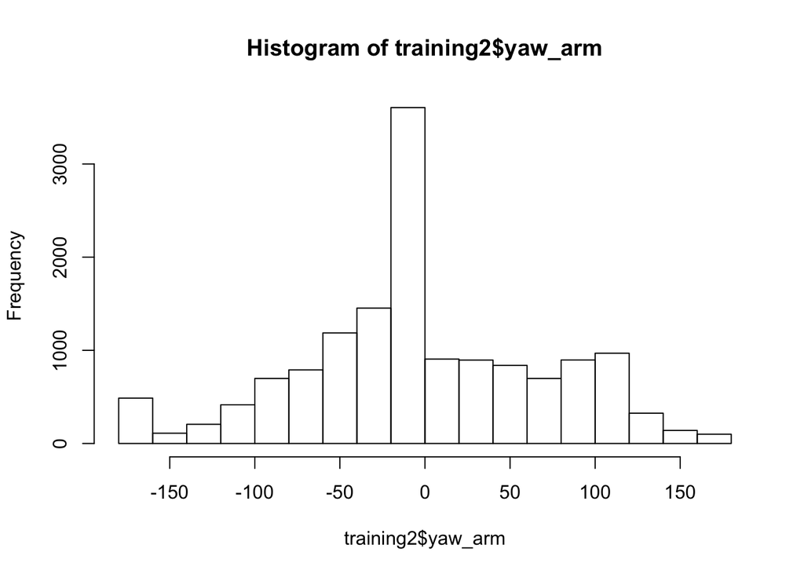

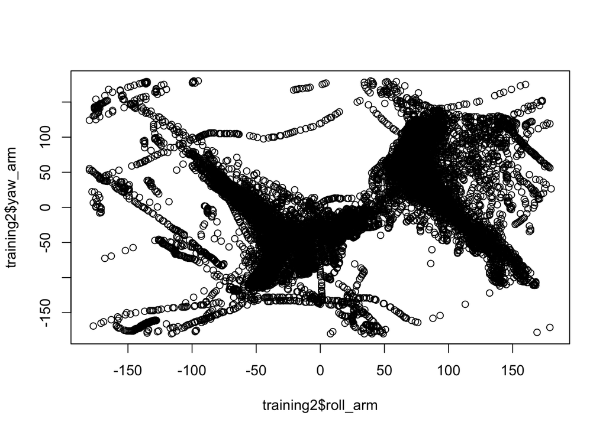

```r
hist(training2$roll_arm); hist(training2$yaw_arm); plot(training2$roll_arm, training2$yaw_arm)
```

```r
dim(training2)
```

```
## [1] 14718    53
```

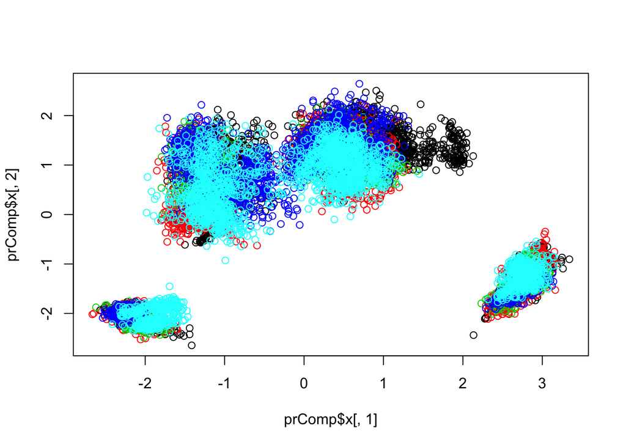

```r
prComp<-prcomp(log10(abs(training2[,-53])+1))
plot(prComp$x[,1], prComp$x[,2], col=training2$classe)
```

Because the variable classe is a factor variable with five levels, and because of the irregular distribution of the variables, we fit a model on the training data using a random forest approach. Note that this approach requires no pre-processing of the data.

```r
set.seed(2003)
modelfit<-train(classe~., data=training2, method="rf")
```

```r
modelfit
```

Random Forest

14718 samples 52 predictor 5 classes: ‘A’, ‘B’, ‘C’, ‘D’, ‘E’

No pre-processing Resampling: Bootstrapped (25 reps) Summary of sample sizes: 14718, 14718, 14718, 14718, 14718, 14718, … Resampling results across tuning parameters:

mtry Accuracy Kappa  
2 0.9898713 0.9871848 27 0.9904840 0.9879615 52 0.9809981 0.9759593

Accuracy was used to select the optimal model using the largest value. The final value used for the model was mtry = 27. This model predicts the variable classe in the training data set with an accuracy of .99. We next validate the model using the validation data set.

```r
pred<-predict(modelfit, newdata=validation)
validpredright<-pred==validation$classe
table(pred, validation$classe)
```

```
##
## pred    A    B    C    D    E
##    A 1393    7    0    0    0
##    B    1  938    3    0    1
##    C    0    4  851    7    4
##    D    0    0    1  796    3
##    E    1    0    0    1  893
```

Here we see that out of 4904 cases in the validation set, the model predicts 4871 correctly, for an accuracy rate of .99.